# Assignment 3

Data Science for Biomedical Informatics (BMIN503/EPID600)

###Instructions - Download the Rmd version of this file - Complete the questions below in RStudio using the Rmd file as a template - Replace text in brackets with your answers. (There is no need to keep the brackets). - Save the Rmd document as Assignment3_*YOUR LAST NAME*.Rmd - Create an HTML version using knitr - Turn in completed Assignment3_*YOUR LAST NAME*.html file in Canvas under Assignments -> Assignment 3 - Your assignment **must** be in html format or it will not be graded - Grades will be assigned according to point scheme below and computed as a percentage of total possible points - Lateness policy: If an urgent and unforseen circumstance comes up and you need an extension to turn in an assignment, please contact Blanca and/or Sherrie as soon as possible. Unless there is an arrangement in place, late assignments will be scored as follows: - 25% of total score if 1 day late - 50% of total score if 2 days late - 75% of total score if 3 days late - Assignment will not be graded if 4 or more days late - DUE DATE: 10/5/18

###Final Project - Repository 1. Fork the [Final Project Repository](https://github.com/HimesGroup/BMIN503_Final_Project) to your GitHub account, and then pull this repository as a new project on your local computer by using the *Project* menu in the upper-right-hand corner of RStudio, selecting a *New Project*, creating it via *Version Control* -> *Git* -> and entering your GitHub repository (remember to append `.git` to the copied `url`). You can now work on your final project from your computer, and easily push updates to your GitHub account, where the final version will be saved. A *Git* tab will be available that you can use to *Pull*, *Commit*, and *Push* changes between your local version and that on GitHub without having to use the command line. *(1 point for forking repository)*

https://github.com/DataAndDeadlifts/BMIN503_Final_Project

2. In 2-3 sentences, describe what question you will answer for your final project and what data will you use. There is a list of public data sources at the bottom of the [Optional Reading](https://github.com/HimesGroup/BMIN503/blob/master/Module1_Optional_Reading.Rmd) document that you can look through if you are having difficulty identifying public data. If you’d like help to pick a question, please let Blanca or Sherrie know soon. *(2 points)*

> I plan to group and map protein structure characteristics to disease and pathologys. Perhaps predict proteins with known structure but no known link to disease using the classification/grouping model I build.
3. What three faculty/staff (name, title, division/department) have you met or are planning to meet to discuss your project? *(2 points)*

> Dr. Jason Moore (jhmoore@upenn.edu), Professor and Director of Informatics in the Department of Biostatistics and Epidemiology Roland L. Dunbrack (Roland.Dunbrack@fccc.edu), Jr. Ph.D., Adjunct Professor of Biochemistry & Biophysics Dr. Graciela Gonzalez (gragon@upenn.edu), Professor of Computer and Information Science

### Cleaning and Transforming data, Descriptive Statistics and Regression

4. Install and load the `nycflights13` package to do this problem. This package includes the flights dataset, which contains information on 336,776 flights that departed from New York City in 2013 and is often used to learn `dplyr` commands. If you need more guided practice with `dplyr`, beyond what we did in class, you can go through this [vignette](https://cran.r-project.org/web/packages/dplyr/vignettes/dplyr.html). Use `dplyr` to answer the following questions by inserting code below each bullet to provide the answer directly. *(10 points)*

```r
#install.packages("nycflights13")
#install.packages("dplyr")
#install.packages("ggplot2")
library("dplyr")
library("ggplot2")
# NYC airports include JFK, EWR and LGA
flights <- nycflights13::flights
# Num carriers departed NYC in 2013
n_carriers = nrow(distinct(flights['carrier']))
print("Num carriers that departed NYC in 2013;")
```

```
## [1] "Num carriers that departed NYC in 2013;"
```

```r
print(n_carriers)
```

```
## [1] 16
```

```r
# Are there any origins beside NYC?
distinct(flights['origin'])
```

```
## # A tibble: 3 x 1
##   origin
##   <chr>
## 1 EWR
## 2 LGA
## 3 JFK
```

```r
# Looks like there isn't, no need to filter then!
carrier_flight_count <- table(flights$carrier)
max_carrier <- names(which(carrier_flight_count==max(carrier_flight_count)))
print("Carrier with most flights")
```

```
## [1] "Carrier with most flights"
```

```r
print(max_carrier)
```

```
## [1] "UA"
```

```
+ Of the flights that departed in June and July, how many unique tailnum contained the letter M or P?
```

```r
# Get unique tailnums in June, July flights
unique_tails <- distinct(filter(flights, month==6 | month==7)['tailnum'])
# Get tails that contain M or P
m_or_p_tails <- filter(unique_tails, grepl("M",tailnum) | grepl("P",tailnum))
print("Number of tailnums from flights in june and july that contain the letter M or P.")
```

```
## [1] "Number of tailnums from flights in june and july that contain the letter M or P."
```

```r
print(nrow(m_or_p_tails))
```

```
## [1] 261
```

```
+ What was the most popular destination each month?
```

```r
pop_dest_by_month <- summarize(group_by(flights,month,dest),count =n()) %>%
  filter(count==max(count))
pop_dest_by_month
```

```
## # A tibble: 12 x 3
## # Groups:   month [12]
##    month dest  count
##    <int> <chr> <int>
##  1     1 ATL    1396
##  2     2 ATL    1267
##  3     3 ATL    1448
##  4     4 ATL    1490
##  5     5 ORD    1582
##  6     6 ORD    1547
##  7     7 ORD    1573
##  8     8 ORD    1604
##  9     9 ORD    1582
## 10    10 ORD    1604
## 11    11 ATL    1384
## 12    12 ATL    1463
```

```
+ Was the mean departure delay time per carrier related to the total number of flights per carrier? The answer should show a plot and use one sentence to address this question qualitatively.
```

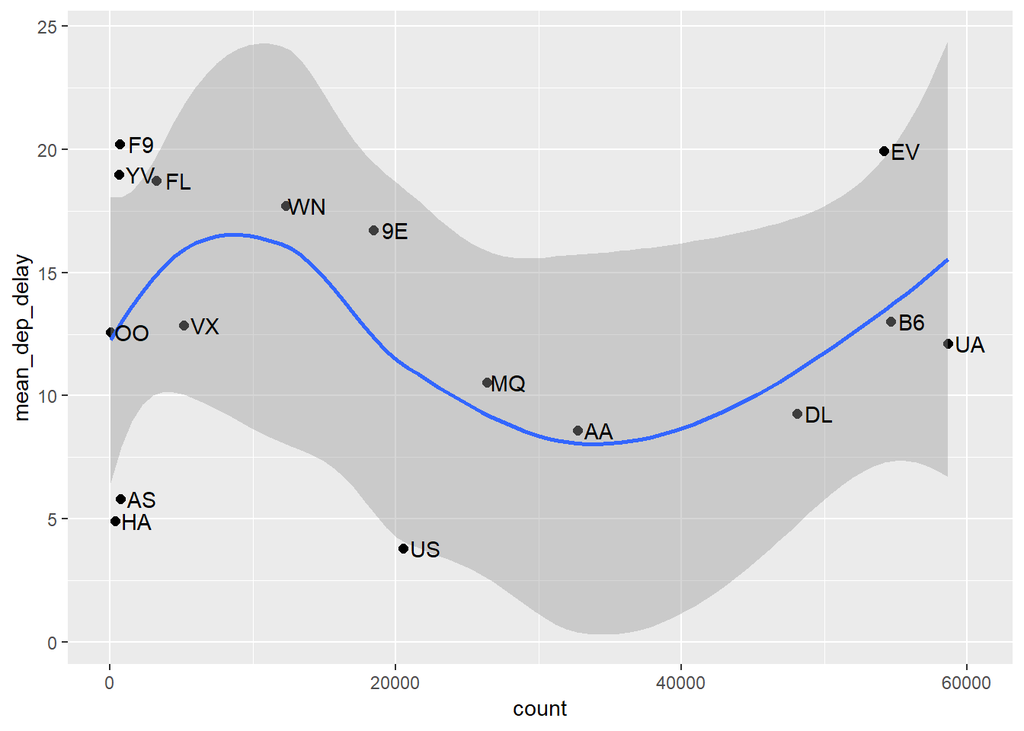

```r
count_carrier_delay <- summarize(group_by(flights,carrier),count =n(), mean_dep_delay=mean(dep_delay, na.rm=T))

ggplot(count_carrier_delay, aes(x=count, y=mean_dep_delay)) +
  geom_point(size=2) +
  geom_smooth(method="loess",se=TRUE,fullrange=FALSE, level=0.95) +
  geom_text(label=count_carrier_delay$carrier, nudge_x=1500)
```

There doesn’t appear to be any kind of clear link between number of flights and mean departure delay based on this data. Reasonable hypotheses before seeing this data may be either 1. Mean Dept delay increases with flight count - as there are more opportunities for errors to be made in organizing the flight… or 2. Mean Dept delay may decrease with flight count, as the number of flights increases the expertise of the airline, leading to better organization of flights. Neither of these hypotheses are supported by the data for NYC in 2013. There is no strong and clear linear relationship between flight count and mean departure delay.

```
+ Was the mean delay time for a given time of departure related to the time of departure? The answer should show a plot and use one sentence to address this question qualitatively.
```

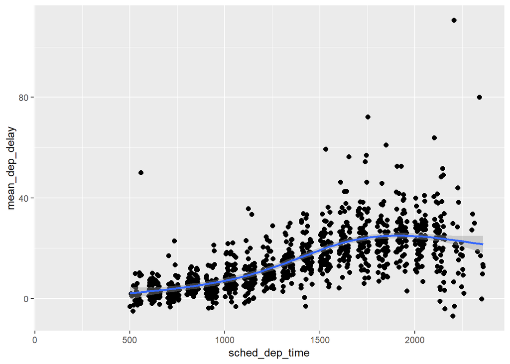

```r
time_of_day_delay <- summarize(group_by(flights,sched_dep_time), mean_dep_delay=mean(dep_delay, na.rm=T))

ggplot(time_of_day_delay, aes(x=sched_dep_time, y=mean_dep_delay)) +
  geom_point(size=2) +
  geom_smooth(method="auto",se=TRUE,fullrange=FALSE, level=0.95)
```

The method of regression against these variables displays a high level of confidence in it’s fit. This belies a strong relationship between sched_dep_time and mean_dep_delay. Around 1800-1900 during the day there is a much higher average delay time paired with a high confidence (low range) confidence interval over that period. If I were flying out of NYC in 2013 I would definitely avoid 7PM and instead try to schedule flights that depart at 5AM if I really don’t want to be delayed.

5. Load the `MASS` package, which contains the [birthwt](https://stat.ethz.ch/R-manual/R-devel/library/MASS/html/birthwt.html) dataset, to answer the following questions. We will work toward identifying variables that are associated with low birthweight, both as a dichotomous outcome and a continuous one. HINT: The `MASS` package contains a `select` command that may compete with that from `dplyr`. If you have `dplyr` and `MASS` loaded simultaneously and want to use `dplyr`’s `select`, do it explicitly. For example, use `dplyr::select` rather than `select`. *(9 points)*

```r
#install.packages("MASS")
library("MASS")
```

```r
birthwt <- birthwt
#str(birthwt)
# 1
birthwt.clean <-  dplyr::select(birthwt,low.birth.wt=low, birth.wt=bwt, age, race, smoke, hypertension=ht, prem.labor=ptl)
# 2
integer_cols <- c('low.birth.wt','race','smoke','hypertension','prem.labor')
birthwt.clean$low.birth.wt <- factor(birthwt.clean$low.birth.wt, labels=c("normal","low"))
birthwt.clean$race <- factor(birthwt.clean$race, labels=c("white","black","other"))
birthwt.clean$smoke <- factor(birthwt.clean$smoke, labels=c("non-smoking","smoking"))
birthwt.clean$hypertension <- factor(birthwt.clean$hypertension, labels=c("no-history","history"))
# 3
birthwt.clean <- filter(birthwt.clean, race!="other")
# 4
birthwt.clean$prem.labor <- factor(ifelse(as.numeric(as.character(birthwt.clean$prem.labor))==0, 0, 1))
birthwt.clean$prem.labor <- factor(birthwt.clean$prem.labor, labels=c("no-history","history"))

str(birthwt.clean)
```

```
## 'data.frame':    122 obs. of  7 variables:
##  $ low.birth.wt: Factor w/ 2 levels "normal","low": 1 1 1 1 1 1 1 1 1 1 ...
##  $ birth.wt    : int  2523 2557 2594 2600 2637 2663 2665 2769 2769 2778 ...
##  $ age         : int  19 20 21 18 22 29 26 18 18 15 ...
##  $ race        : Factor w/ 3 levels "white","black",..: 2 1 1 1 1 1 1 1 1 2 ...
##  $ smoke       : Factor w/ 2 levels "non-smoking",..: 1 2 2 2 1 2 2 2 2 1 ...
##  $ hypertension: Factor w/ 2 levels "no-history","history": 1 1 1 1 1 1 1 1 1 1 ...
##  $ prem.labor  : Factor w/ 2 levels "no-history","history": 1 1 1 1 1 1 1 1 1 1 ...
```

[output not shown]

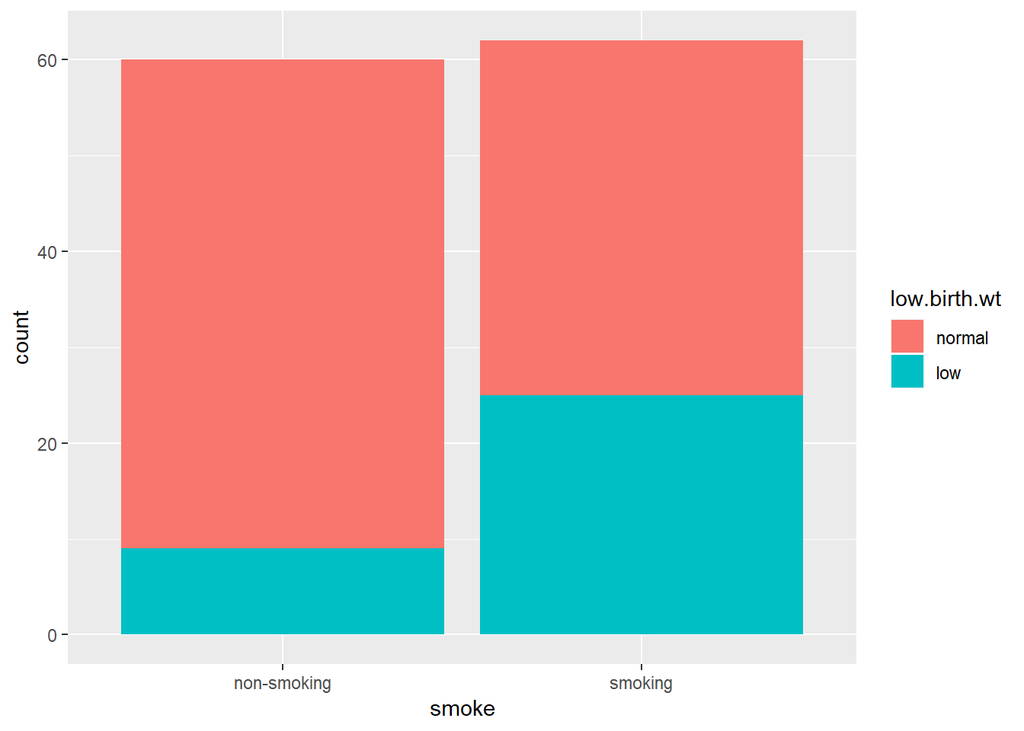

```r
# Smoke vs low.birth.wt and birth.wt
ggplot(birthwt.clean, aes(smoke)) +
  geom_bar(aes(fill=low.birth.wt))
```

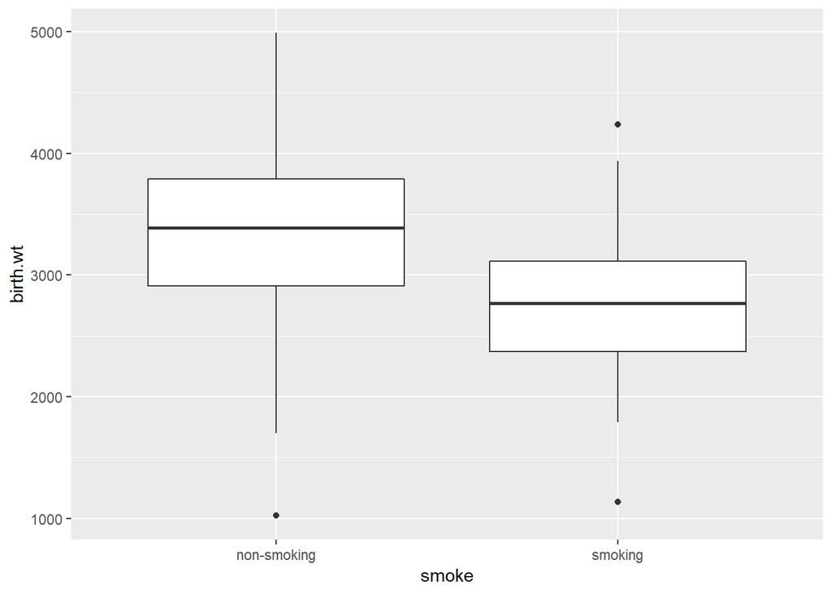

```r
ggplot(birthwt.clean, aes(x=smoke, y=birth.wt)) +
  geom_boxplot()
```

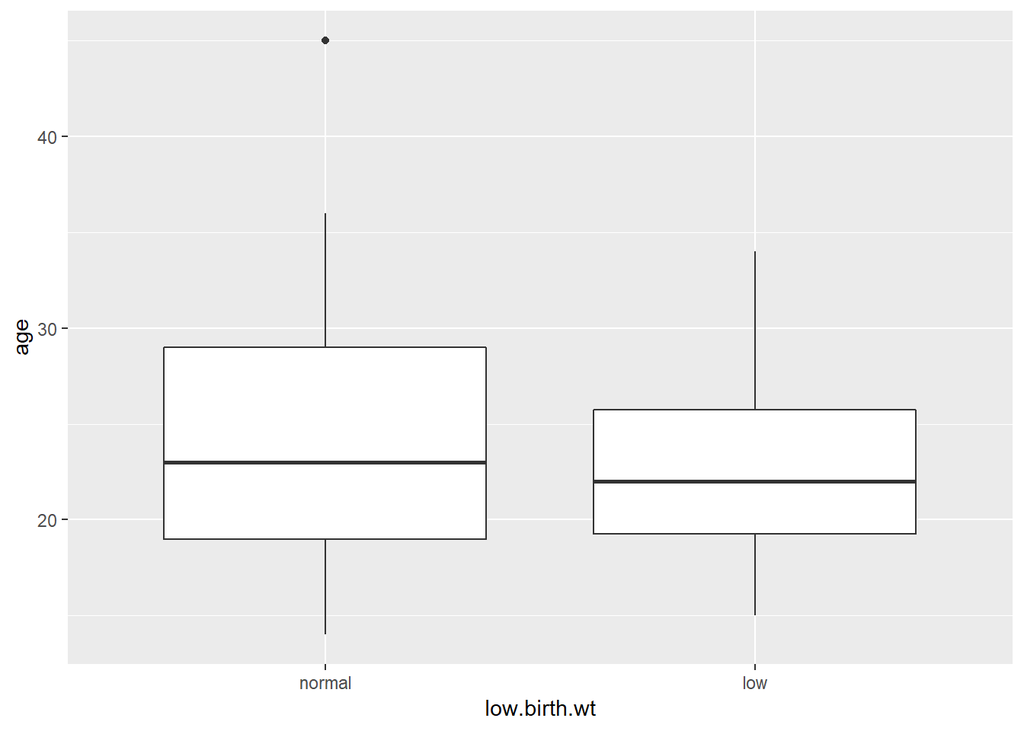

```r
# Age vs low.birth.wt and birth.wt
ggplot(birthwt.clean, aes(x=low.birth.wt, y=age)) +
  geom_boxplot()
```

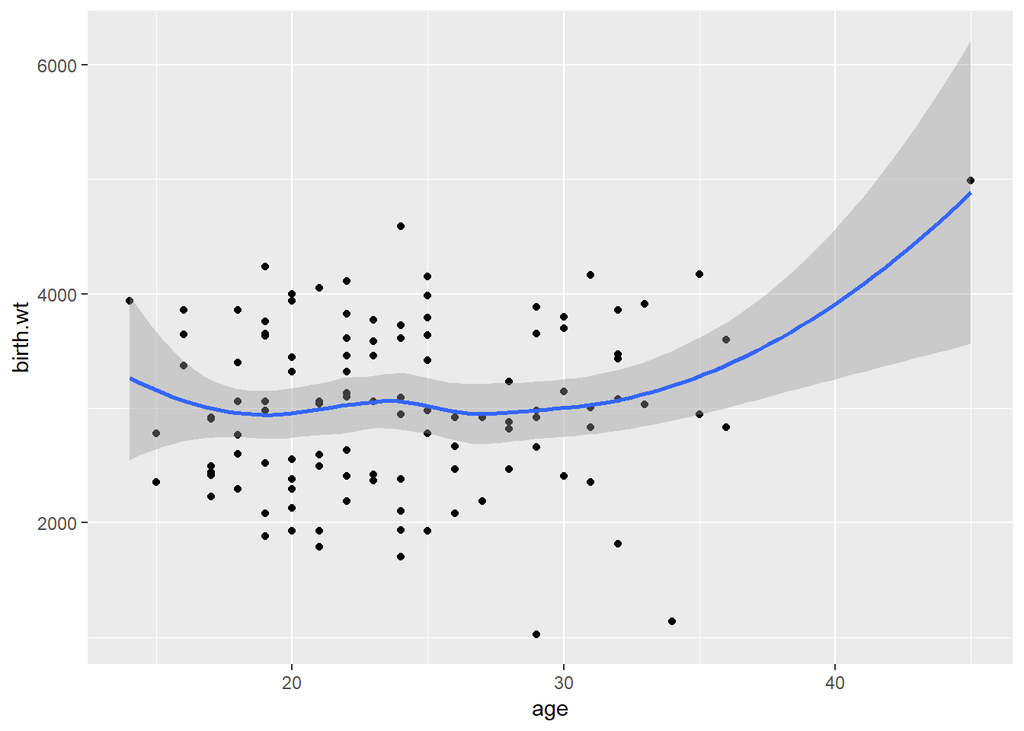

```r
ggplot(birthwt.clean, aes(x=age,y=birth.wt)) +
  geom_point() +
  geom_smooth(method="auto",se=TRUE,fullrange=FALSE, level=0.95)
```

```r
# Smoke x low.birth.wt contingency table
smoke_by_lowbirthwt <- table(birthwt.clean[, c('smoke', 'low.birth.wt')])
print("Smoke X low.birth.wt contingency table test (chi-squared):")
```

```
## [1] "Smoke X low.birth.wt contingency table test (chi-squared):"
```

```r
chisq.test(smoke_by_lowbirthwt)
```

```
##
##  Pearson's Chi-squared test with Yates' continuity correction
##
## data:  smoke_by_lowbirthwt
## X-squared = 8.5076, df = 1, p-value = 0.003537
```

```r
# Smoke x birth.wt t-test
x1 = filter(birthwt.clean, smoke=='non-smoking')$birth.wt
x2 = filter(birthwt.clean, smoke=='smoking')$birth.wt
print("Smoke x birth.wt t-test:")
```

```
## [1] "Smoke x birth.wt t-test:"
```

```r
t.test(x1, x2)
```

```
##
##  Welch Two Sample t-test
##
## data:  x1 and x2
## t = 4.0434, df = 116.6, p-value = 9.491e-05
## alternative hypothesis: true difference in means is not equal to 0
## 95 percent confidence interval:
##  255.5243 746.1606
## sample estimates:
## mean of x mean of y
##  3275.617  2774.774
```

```r
# low.birth.wt x age t-test
n1 = filter(birthwt.clean, low.birth.wt=='normal')$age
n2 = filter(birthwt.clean, low.birth.wt=='low')$age
print("Age x low.birth.wt t-test:")
```

```
## [1] "Age x low.birth.wt t-test:"
```

```r
t.test(n1, n2)
```

```
##
##  Welch Two Sample t-test
##
## data:  n1 and n2
## t = 1.2231, df = 74.307, p-value = 0.2252
## alternative hypothesis: true difference in means is not equal to 0
## 95 percent confidence interval:
##  -0.7942047  3.3196058
## sample estimates:
## mean of x mean of y
##  24.05682  22.79412
```

```r
# birth.wt x age spearman correlation
print("Age x birth.wt spearman correlation test")
```

```
## [1] "Age x birth.wt spearman correlation test"
```

```r
cor.test(birthwt.clean$age, birthwt.clean$birth.wt, method="spearman")
```

```
##
##  Spearman's rank correlation rho
##
## data:  birthwt.clean$age and birthwt.clean$birth.wt
## S = 274340, p-value = 0.3059
## alternative hypothesis: true rho is not equal to 0
## sample estimates:
##        rho
## 0.09345406
```

1. Smoking and low.birth.wt. It appears that smoking and low birth weight have a statistically significant association with a p-value of 0.003537. Smoking likely has an effect on whether a baby is born with a low birth weight.
2. Smoking and birth.wt. It appears according to the data that smoking affects birth weight at a statistically significant level (0.05 p-value cutoff). The distribution of birth weights have a significantly different mean when split by smoking status of the mother. Smoking is therefore likely to have a harmful effect on birth weight according to this data.
3. Age and low.birth.wt. According to this data age does not have a statistically significant effect on birth weight at a 0.05 significance level. Age likely does not have a significant effect on low birth weight.
4. Age and birth.wt. According to this data age does not have a statistically significant effect on birth weight at a p-value cutoff of 0.05. Age is not likely to have an effect on birth weight according to this data.
   - Create multivariable regression models for `low.birth.wt` and `bwt` using `age`, `race`, `smoke`, `hypertension`, and `prem.labor` as predictors. What factors are significantly associated with the birth weight outcomes?

```r
lowbwt_model <- glm(low.birth.wt ~ age + race + smoke + hypertension + prem.labor, birthwt.clean, family='binomial')

print("Low birth weight model:")
```

```
## [1] "Low birth weight model:"
```

```r
summary(lowbwt_model)
```

```
##
## Call:
## glm(formula = low.birth.wt ~ age + race + smoke + hypertension +
##     prem.labor, family = "binomial", data = birthwt.clean)
##
## Deviance Residuals:
##     Min       1Q   Median       3Q      Max
## -1.6272  -0.8052  -0.4323   0.9780   2.2986
##
## Coefficients:
##                     Estimate Std. Error z value Pr(>|z|)
## (Intercept)         -1.47793    1.13864  -1.298  0.19429
## age                 -0.03759    0.04517  -0.832  0.40535
## raceblack            1.09873    0.53415   2.057  0.03969 *
## smokesmoking         1.35155    0.50231   2.691  0.00713 **
## hypertensionhistory  1.04344    0.77843   1.340  0.18010
## prem.laborhistory    1.35777    0.58036   2.340  0.01931 *
## ---
## Signif. codes:  0 '***' 0.001 '**' 0.01 '*' 0.05 '.' 0.1 ' ' 1
##
## (Dispersion parameter for binomial family taken to be 1)
##
##     Null deviance: 144.38  on 121  degrees of freedom
## Residual deviance: 121.98  on 116  degrees of freedom
## AIC: 133.98
##
## Number of Fisher Scoring iterations: 4
```

```r
bwt_model <- lm(birth.wt ~ age + race + smoke + hypertension + prem.labor, birthwt.clean)

print("Birth weight model:")
```

```
## [1] "Birth weight model:"
```

```r
summary(bwt_model)
```

```
##
## Call:
## lm(formula = birth.wt ~ age + race + smoke + hypertension + prem.labor,
##     data = birthwt.clean)
##
## Residuals:
##      Min       1Q   Median       3Q      Max
## -2416.01  -370.74     9.87   449.21  1477.05
##
## Coefficients:
##                     Estimate Std. Error t value Pr(>|t|)
## (Intercept)         3299.358    294.696  11.196  < 2e-16 ***
## age                    4.746     11.123   0.427 0.670375
## raceblack           -436.628    152.273  -2.867 0.004917 **
## smokesmoking        -498.975    126.584  -3.942 0.000139 ***
## hypertensionhistory -155.622    245.796  -0.633 0.527893
## prem.laborhistory   -230.093    176.534  -1.303 0.195022
## ---
## Signif. codes:  0 '***' 0.001 '**' 0.01 '*' 0.05 '.' 0.1 ' ' 1
##
## Residual standard error: 660.4 on 116 degrees of freedom
## Multiple R-squared:  0.2038, Adjusted R-squared:  0.1695
## F-statistic: 5.939 on 5 and 116 DF,  p-value: 6.316e-05
```

If I’m interpreting this correctly, age negatively impacts the babies likelihood in having a low birth weight and all other factors (race being black, smoking, hypertension and premature labor history) all increasing the likelihood of a low birth weight. Of these factors, a history of premature labor in the mother is the highest estimator in a low birth weight.

The birth weight model esimates that all factors except age predict a lower birth weight with their being “positive” or present (as if happening, ex the mother smoking or the mom having hypertension). Given these factors, smoking seems to have the highest predictive and negative impact on the resulting birth weight.